# Berend’s portfolio, homework 8 version

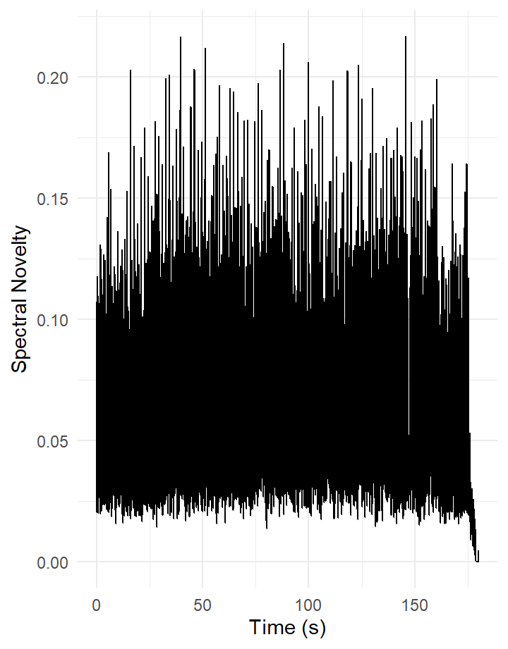

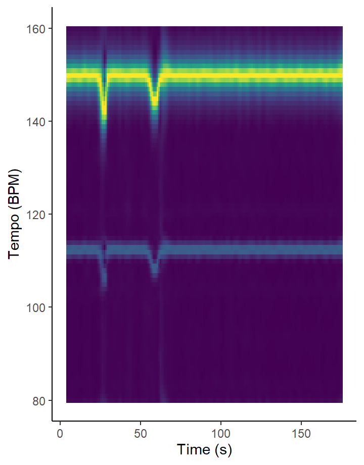

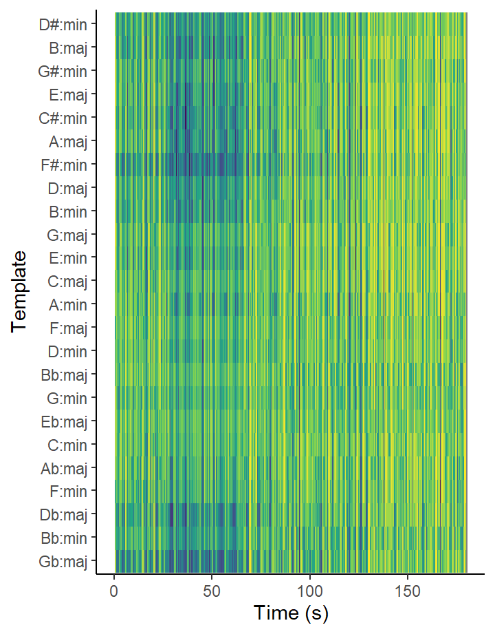

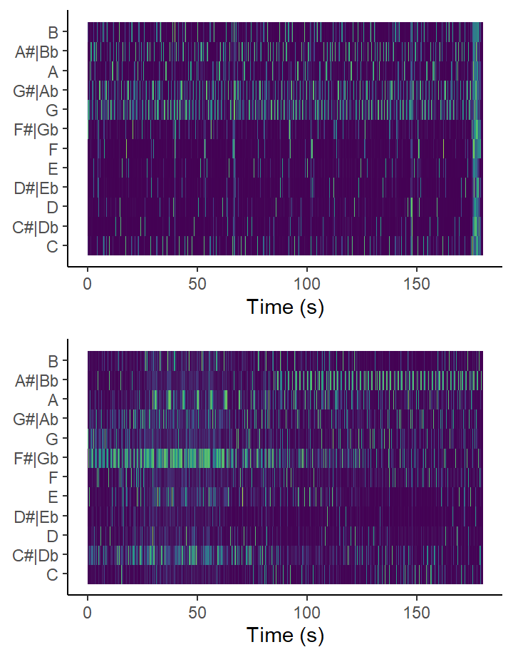

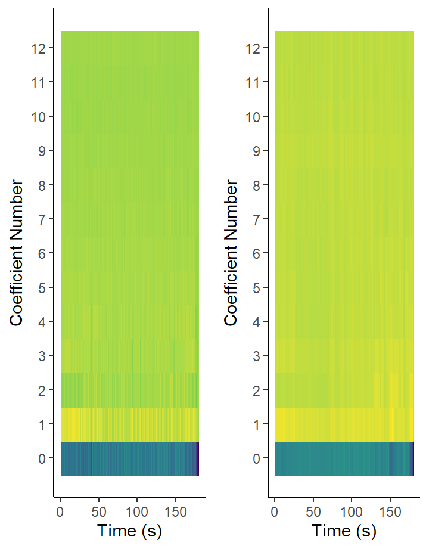

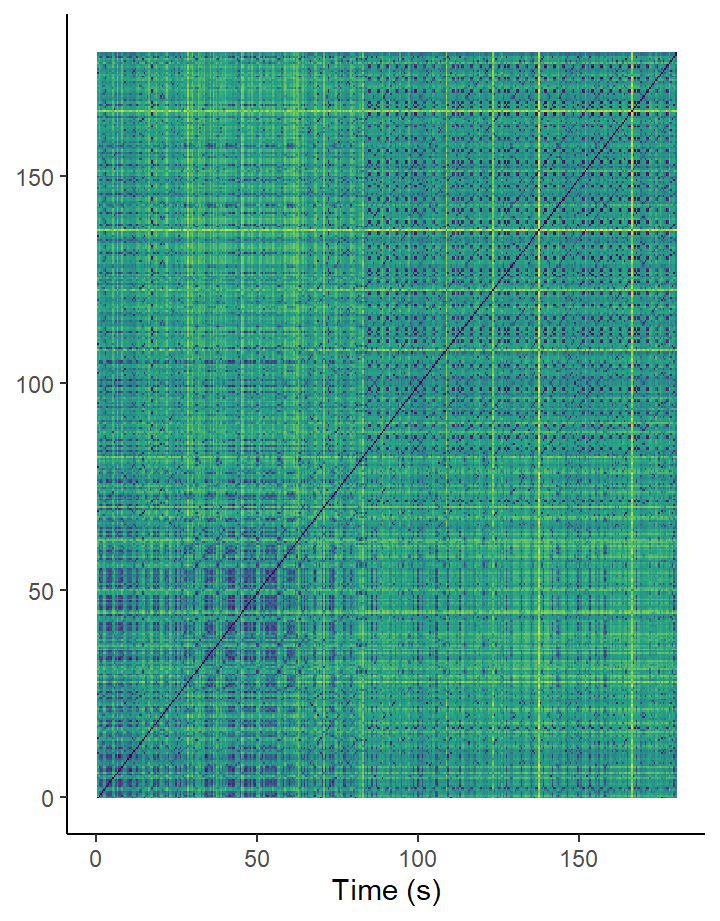

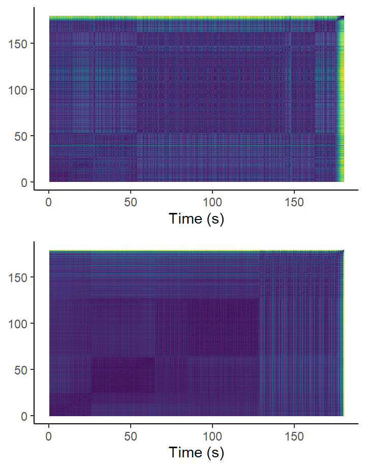

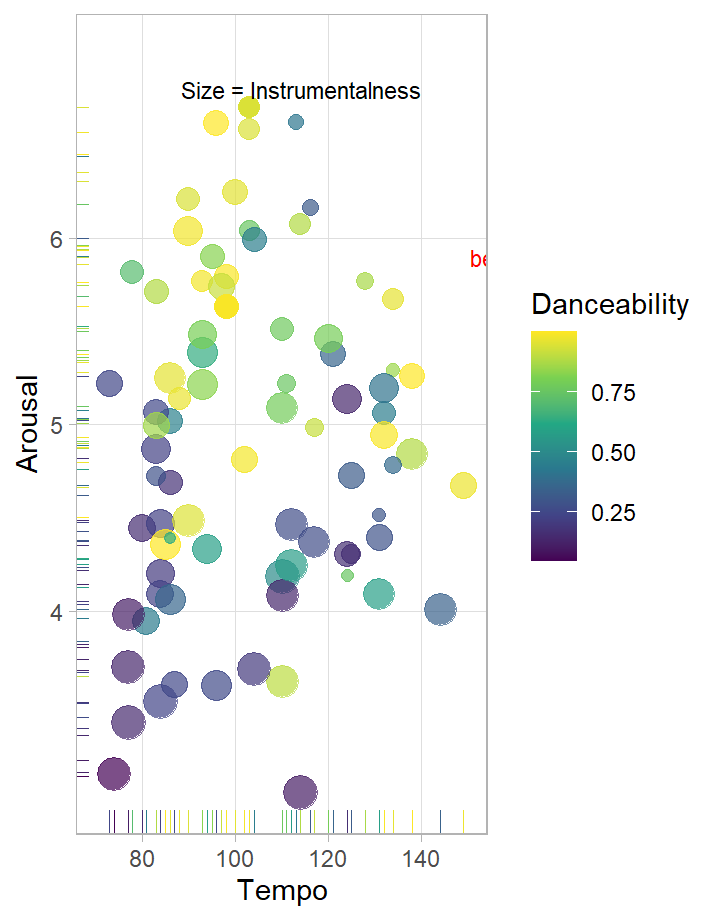

### Novelty Functions

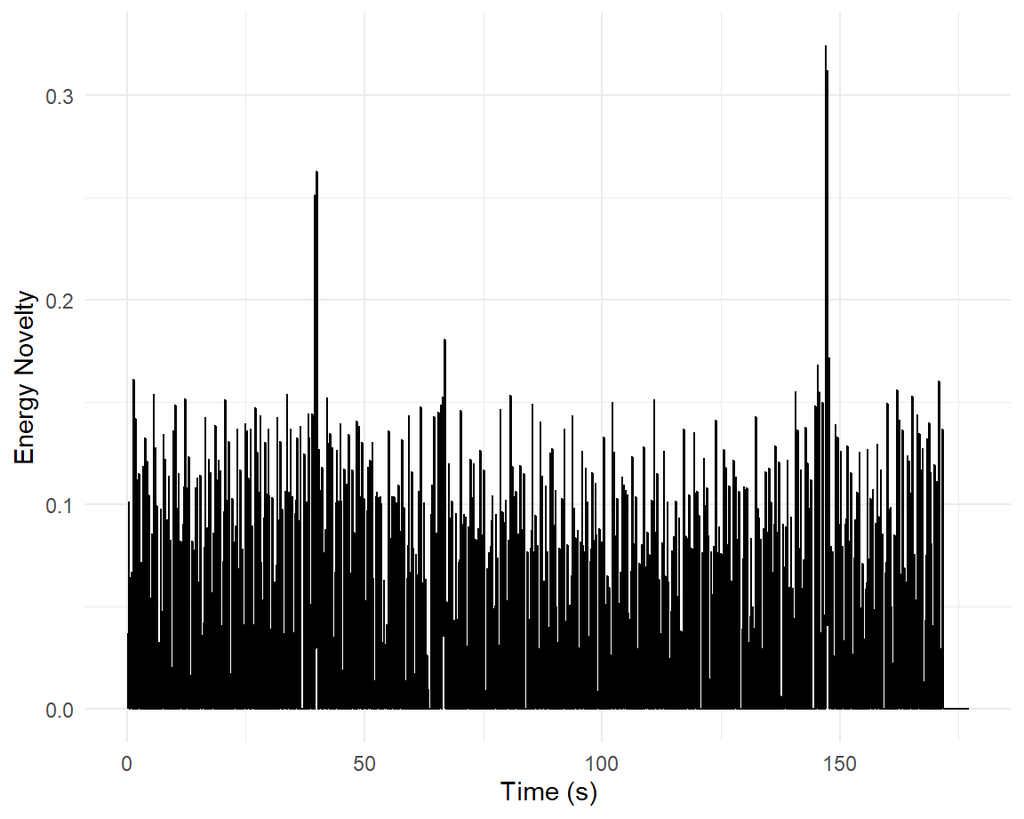

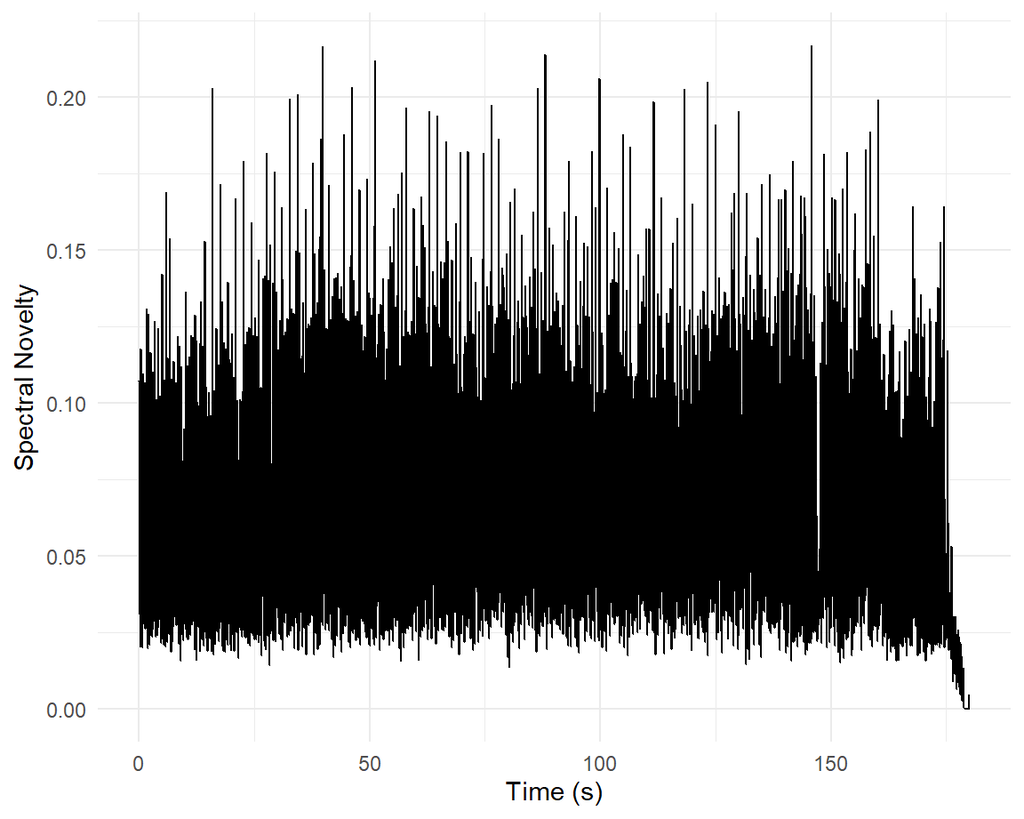

Here one can see my energy novelty and spectral novelty functions of my first song.

### Tempograms

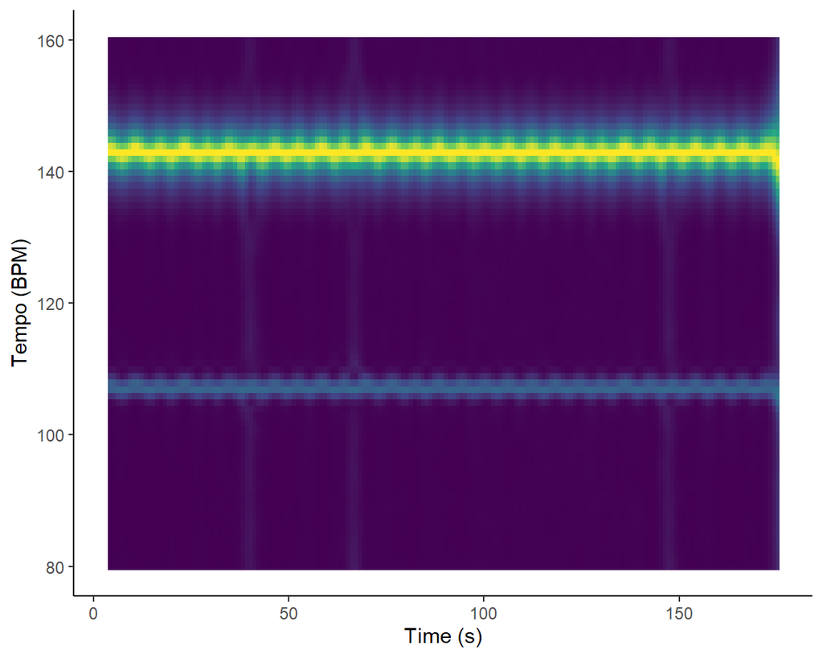

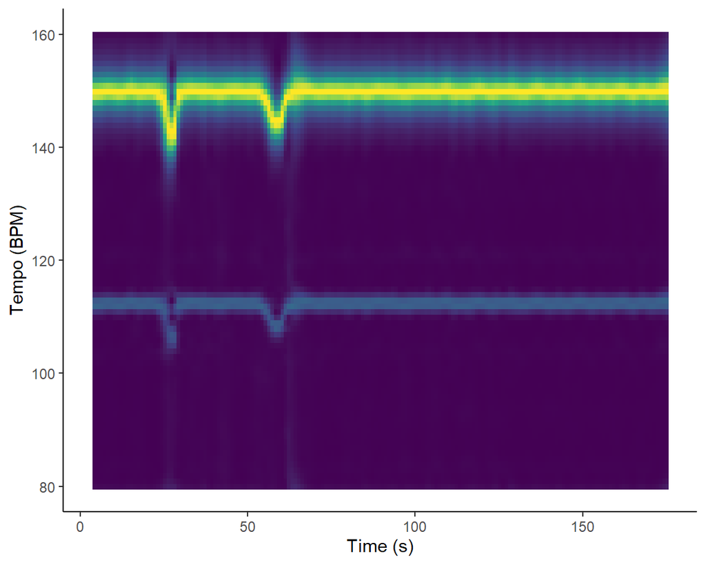

Dit zijn mijn tempograms, (cyclic = TRUE).

### Chordagrams

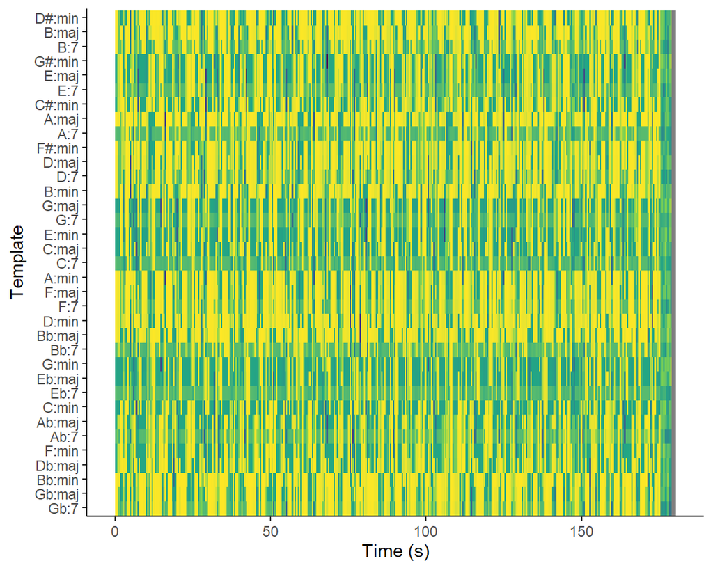

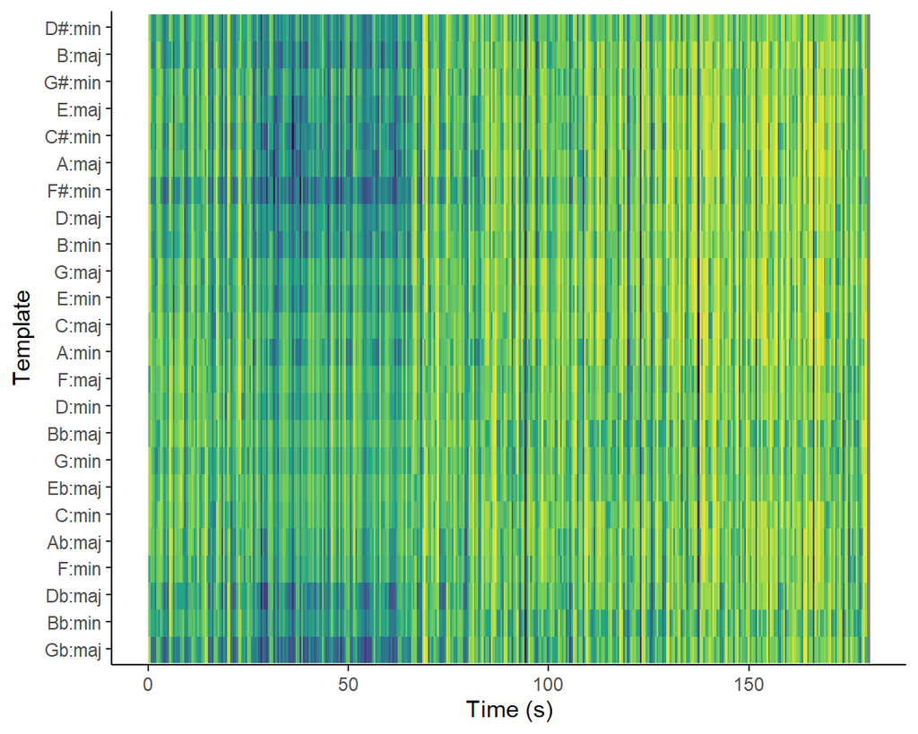

Here are my two chordagrams. For the first song I used the chord templates with manhattan distance and norm. For the second song I went with the key templates and an euclidean norm and angular distance metric.

### Chromagrams

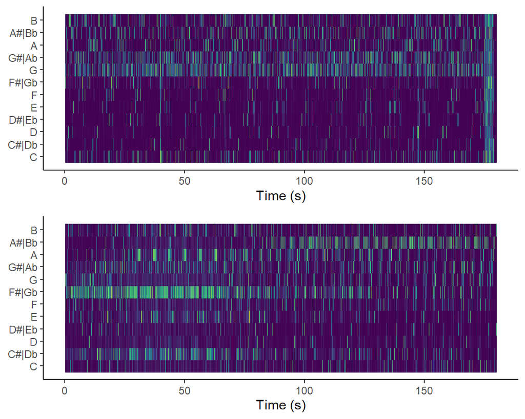

These are the chromagrams of my own AI songs. The upper plot is from the first song, and the lower plot is the second song. All the following visualisations and plots will follow that order as well, from left to right as well.

### Cepstrograms

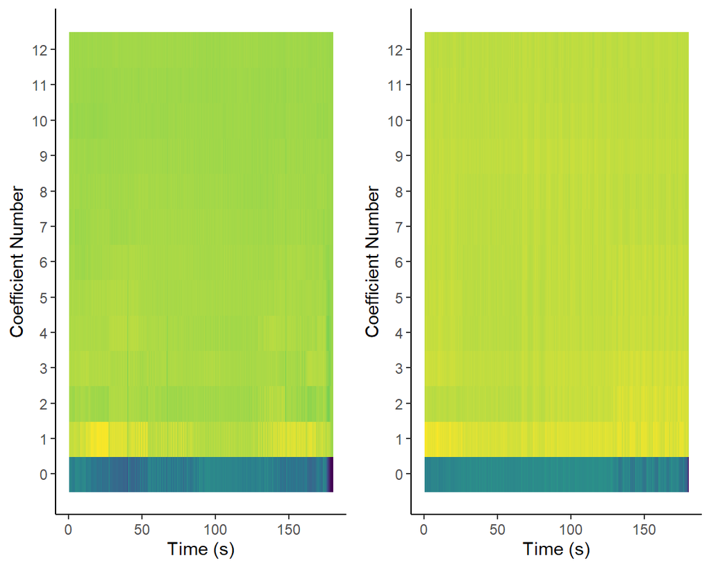

### Self similarity matrixes

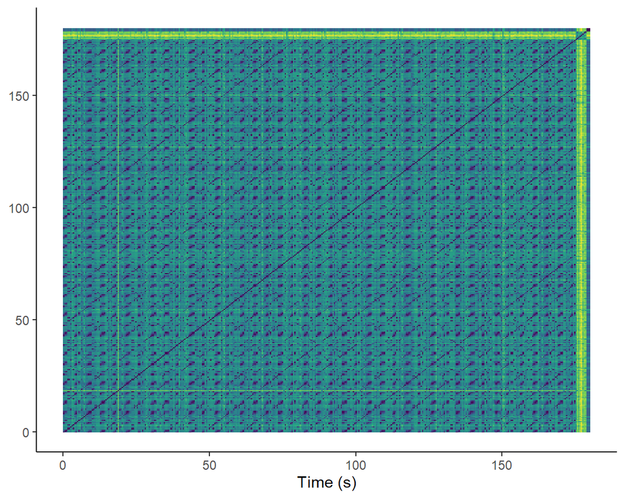

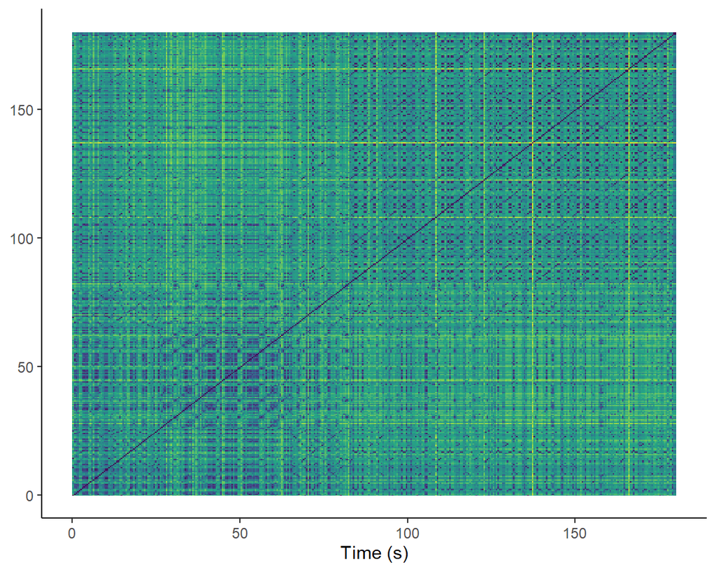

The self similarity matrixes show that my songs are quite similar. Especially the 1st song.

### Timbre based self similarity matrixes

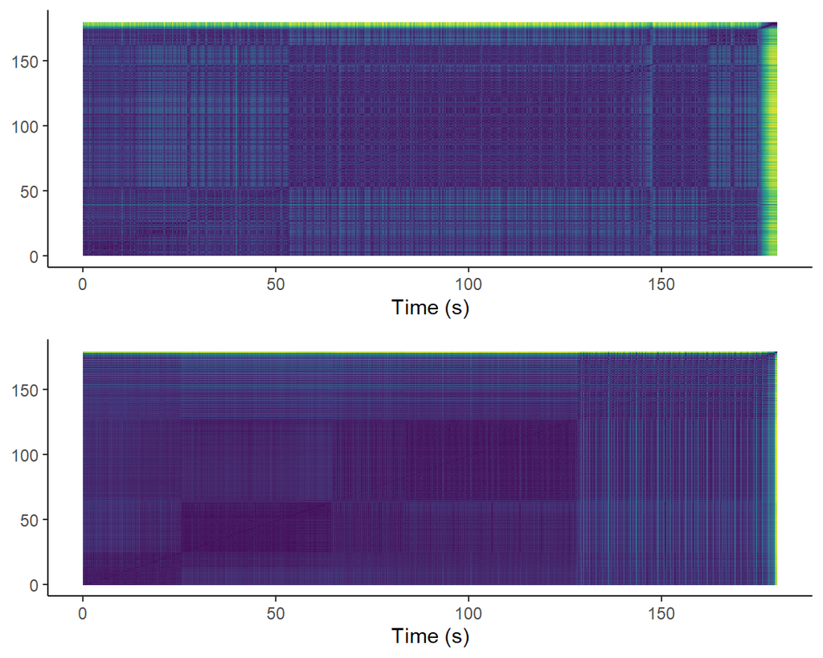

The timbre based self similarity matrixes show that my songs are quite similar too, although there is a bit more difference visible.

### Welcome to my github page on musicology!

**(This and the next page should normally be at the beginning)**

Dear reader, I welcome you to my github page. On the next tab you will find some visualisations of the class corpus.

For this portfolio I have created two songs using AI. The prompts for these songs can be found on the at the bottom of the page. The songs I have created using AI were inspired by some of these songs below. Now, I would like to give you a small challenge: either have a listen to these songs first and then come up with a prompt, to try to make a similar song to the songs below. After this, have a look at the prompts I have used to try and create similar songs. Did these match your idea of the best prompt?

Alternatively, you can take a look at my prompts first, then imagine what this type of music would sound like and then listen to the songs below.

Whichever route you took, be sure to listen to the final result of the AI songs generated by me. Do you think they fit the prompts and/or the songs? They can be found below the prompts at the bottom of the page.

(Currently the embedded links are not working properly, because using them stops the website from appearing as a storyboard. If you still wish to hear what the songs are like you can look up these titles below.)

[interactive chart not shown]

[interactive chart not shown]

[interactive chart not shown]

Here are my AI generated songs. They were created using [StableAudio](https://www.stableaudio.com/) (songs yet to be added)

**Show prompts**

The prompt for the first song was: *“A house/hardgroove beat with high energy and danceability, a blend of hefty kicks with catchy riffs and stabs, with a BPM of 143, the key should be in C# Major and the camelot should be 3B.”*

The prompt for the second song was: *“A hardhouse/trance beat with high energy and danceability, with a bpm of 150, the key should be in F# Minor and the camelot should be 11A. It should have a strong basskick.”*

I came up with these prompts by looking up descriptions of the artists of the songs that I tried to recreate, and copying how their styles were described. I also looked up these songs on [Tunebat](https://tunebat.com/), which is a website that shows lots of musical data on any song via the spotify API.

My first song

[interactive chart not shown]

My second song

[interactive chart not shown]

### Visualising the class corpus and my own genAI tracks

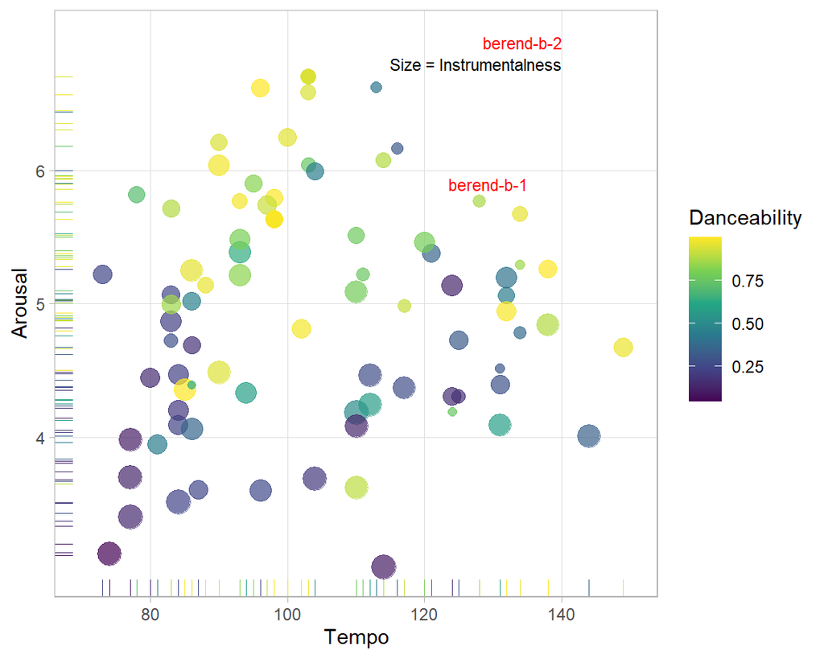

[interactive chart not shown]

This is my visualisation of the class corpus.